# Técnicas Clássicas de Reconhecimento de Padrões (2020/01)

## Exercício 04 - Classificador Bayesiano

**Aluno: Ramon Gomes Durães de Oliveira (2019720188)**

Neste exercício será implementado um classificador Bayesiano. Suas características e propriedades serão explorados em dados sintéticos e, em seguida, nos dados de leucemia (Golub et al 1999).

## Gerando dados sintéticos

Abaixo, serão geradas duas classes sintéticas utilizando gaussianas multivariadas. Uma delas apresentará correlação entre os eixos.

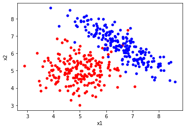

```python
import numpy as np
import pandas as pd
import matplotlib.pyplot as plt
from sklearn.metrics import confusion_matrix
%matplotlib inline

mean1 = np.array((5,5))
cov1 = np.array(((.5, 0.),
                 (0., .5)))
n1 = 200
y1 = 0
data1 = pd.DataFrame(np.random.multivariate_normal(mean1, cov1, n1), columns=['x1','x2'])
data1['y'] = y1

mean2 = np.array((6.5,6.5))
cov2 = np.array(((.8, -0.7),
                 (-0.7, .8)))
n2 = 200
y2 = 1
data2 = pd.DataFrame(np.random.multivariate_normal(mean2, cov2, n2), columns=['x1','x2'])
data2['y'] = y2

colors = {0: 'red', 1: 'blue'}
data = pd.concat([data1, data2])
data.plot.scatter(x='x1', y='x2', c=data['y'].replace(colors))
```

## Classificador Bayesiano

Assume normalidade para as classes

### Média e Covariância Amostral por classe:

```python
def estimate_means_and_covariances(data):
    classes = data.y.unique()
    result = {'covariances': list(),
             'means': list()}
    for c in classes:
        d = data[data['y']==c].loc[:,data.columns != 'y']
        cov = np.cov(d.T)
        mean = np.mean(d).values
        result['covariances'].append(cov)
        result['means'].append(mean)
    return result
```

```python
stats = estimate_means_and_covariances(data)
stats
```

```
{'covariances': [array([[ 0.59159635, -0.05219555],
         [-0.05219555,  0.41875764]]), array([[ 0.72562221, -0.59224901],
         [-0.59224901,  0.66566701]])],
 'means': [array([5.0275359 , 5.00023153]), array([6.52075218, 6.47378106])]}
```

Nota-se que a covariância amostral (estimada acima) é próxima à covariância utilizada para gerar os dados.

### Função de Densidade de Probabilidade Multivariada

Regra de Bayes:

$P(C_i|x) = \frac{P(x|C_i)*P(C_i)}{P(x)}$

Em que $P(C_i)$ é uma contagem, $P(x)$ é um normalizador (não necessário aqui) e $P(x|C_i)$ é o "core" do classificador em si.

Implementando a função de densidade de probabilidade multivariada:

$f(x;\mu,\Sigma)=\frac{1}{\sqrt{(2\pi)^k*det(\Sigma)}}*e^{-\frac{1}{2}*((x-\mu)^T \cdot inv(\Sigma) \cdot (x-\mu))}$

```python
def multivariate_pdf(x, mean, cov):
    size = len(x)
    x = np.array(x).reshape((1, size))
    mean = np.array(mean).reshape((1, size))
    cov = np.array(cov).reshape((size,size))
    if x.shape == mean.shape and (size, size) == cov.shape:
        det = np.linalg.det(cov)
        term1 = 1.0 / ( np.power((2*np.pi),(float(size)/2)) * np.power(det, 0.5))
        term2 = x-mean
        term3 = np.linalg.pinv(cov)
        term4 = np.power(np.e,(-0.5 * np.matmul(np.matmul(term2,  term3), term2.T)))
        return term1 * term4
```

Avaliando a função no primeiro ponto, utilizando as médias e matrizes de covariância relativas a cada uma das classes, espera-se que o valor retornado pela classe 1 seja maior que o valor retornado pela classe 2:

```python
multivariate_pdf(data.loc[:,data.columns!='y'].iloc[0],
                 stats['means'][0],  # mu1
                 stats['covariances'][0]) # Sigma1
```

```
array([[0.06634934]])
```

```python
multivariate_pdf(data.loc[:,data.columns!='y'].iloc[0],
                 stats['means'][1], # mu2
                 stats['covariances'][1]) # Sigma 2
```

```
array([[1.06822561e-12]])
```

De fato este é o caso!

### Visualização da Fronteira de Decisão e das Superfícies de Probabilidade

Calculando as superfícies de densidade de probabilidade para cada classe:

```python
from matplotlib.ticker import LinearLocator, FormatStrFormatter
from matplotlib import cm

X = np.arange(3, 9.25, 0.25)
Y = np.arange(3, 9.25, 0.25)
X, Y = np.meshgrid(X, Y)

Z1 = np.zeros(X.shape)
Z2 = np.zeros(X.shape)

for i in np.arange(X.shape[0]):
    for j in np.arange(X.shape[1]):
        Z1[i, j] = multivariate_pdf([X[i,j], Y[i,j]],
                     stats['means'][0],  # mu1
                     stats['covariances'][0]) # Sigma1
        Z2[i, j] = multivariate_pdf([X[i,j], Y[i,j]],
                     stats['means'][1],  # mu1
                     stats['covariances'][1]) # Sigma1
```

Abaixo, a superfície exibida à esquerda é a PDF resultante da subtração da PDF da classe 1 pela da classe 2. Isso é feito apenas para melhorar a visualização, já que não fariam sentido probabilidades negativas. À direita podemos ver a curva de separação resultante em duas dimensões $\frac{P(x|C_1)}{P(x|C_2)} = 1$.

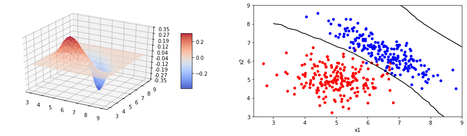

```python
fig = plt.figure(figsize=plt.figaspect(0.25))
ax = fig.add_subplot(1, 2, 1, projection='3d')
surf1 = ax.plot_surface(X, Y, Z1-Z2, cmap=cm.coolwarm, alpha = 0.5,
                        linewidth=0, antialiased=False)

#surf2 = ax.plot_surface(X, Y, Z2, cmap=cm.cool, alpha = 0.5,
#                        linewidth=0, antialiased=False)

# Customize the z axis.
ax.set_zlim(-.35, .35)
ax.zaxis.set_major_locator(LinearLocator(10))
ax.zaxis.set_major_formatter(FormatStrFormatter('%.02f'))

# Add a color bar which maps values to colors.
fig.colorbar(surf1, shrink=0.5, aspect=5)


ax1 = fig.add_subplot(1, 2, 2)
data.plot.scatter(x='x1', y='x2', c=data['y'].replace(colors), ax=(ax1))
ax1.contour(X,Y,(Z1/Z2), [1.], colors='k')
```

## Repetindo o processo para um segundo conjunto de dados sintético:

Para explorar as propriedades do classificador, todo o processo acima será repetido para novos dados sintéticos. Dessa vez, haverá desbalanceamento entre as classes e uma delas estará mais concentrada em uma região.

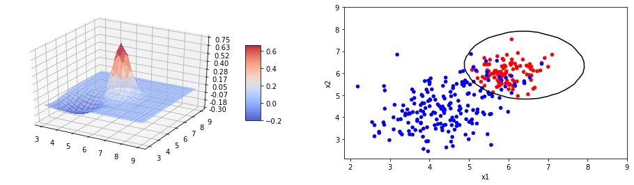

```python
# Gerando os dados
mean1 = np.array((6,6))
cov1 = np.array(((.2, 0.),
                 (0., .2)))
n1 = 100
y1 = 0
data1 = pd.DataFrame(np.random.multivariate_normal(mean1, cov1, n1), columns=['x1','x2'])
data1['y'] = y1

mean2 = np.array((4.5,4.5))
cov2 = np.array(((.8, 0.3),
                 (0.3, .8)))
n2 = 200
y2 = 1
data2 = pd.DataFrame(np.random.multivariate_normal(mean2, cov2, n2), columns=['x1','x2'])
data2['y'] = y2

colors = {0: 'red', 1: 'blue'}
data = pd.concat([data1, data2])

stats = estimate_means_and_covariances(data)
stats

X = np.arange(3, 9.25, 0.25)
Y = np.arange(3, 9.25, 0.25)
X, Y = np.meshgrid(X, Y)

Z1 = np.zeros(X.shape)
Z2 = np.zeros(X.shape)

for i in np.arange(X.shape[0]):
    for j in np.arange(X.shape[1]):
        Z1[i, j] = multivariate_pdf([X[i,j], Y[i,j]],
                     stats['means'][0],  # mu1
                     stats['covariances'][0]) # Sigma1
        Z2[i, j] = multivariate_pdf([X[i,j], Y[i,j]],
                     stats['means'][1],  # mu1
                     stats['covariances'][1]) # Sigma1

fig = plt.figure(figsize=plt.figaspect(0.25))
ax = fig.add_subplot(1, 2, 1, projection='3d')
surf1 = ax.plot_surface(X, Y, Z1-Z2, cmap=cm.coolwarm, alpha = 0.5,
                        linewidth=0, antialiased=False)

#surf2 = ax.plot_surface(X, Y, Z2, cmap=cm.cool, alpha = 0.5,
#                        linewidth=0, antialiased=False)

# Customize the z axis.
ax.set_zlim(-.3, .75)
ax.zaxis.set_major_locator(LinearLocator(10))
ax.zaxis.set_major_formatter(FormatStrFormatter('%.02f'))

# Add a color bar which maps values to colors.
fig.colorbar(surf1, shrink=0.5, aspect=5)


ax1 = fig.add_subplot(1, 2, 2)
data.plot.scatter(x='x1', y='x2', c=data['y'].replace(colors), ax=(ax1))
ax1.contour(X,Y,(Z1/Z2), [1.], colors='k')
```

# Classificando os dados de Leucemia (Golub et al)

## Pré-processamento de dados

Bem como no trabalho anterior, os dados serão limpados e o conjunto de genes mais relevante para a classificação será selecionado antes da classificação em si. As explicações detalhadas de cada processo estão no relatório anterior, de replicação do trabalho de Golub et al. Aqui elas foram removidas por economia de espaço.

### Carregando e Limpeza os Dados

Dados de treinamento

```python
class_df = pd.read_csv('./data/actual.csv')
train_df = pd.read_csv('./data/data_set_ALL_AML_train.csv')
test_df = pd.read_csv('./data/data_set_ALL_AML_independent.csv')

valid_columns = [col for col in train_df.columns if "call" not in col]
train_df = train_df[valid_columns]
train_df = train_df.T
train_df = train_df.drop(['Gene Description','Gene Accession Number'],axis=0)
train_df.index = pd.to_numeric(train_df.index)
train_df.sort_index(inplace=True)
class_dict = {'AML':0,'ALL':1}
train_df['class'] = class_df[:38]['cancer'].replace(class_dict).values
train_df.head()
```

|  | 0 | 1 | 2 | 3 | 4 | 5 | 6 | 7 | 8 | 9 | ... | 7120 | 7121 | 7122 | 7123 | 7124 | 7125 | 7126 | 7127 | 7128 | class |
| --- | --- | --- | --- | --- | --- | --- | --- | --- | --- | --- | --- | --- | --- | --- | --- | --- | --- | --- | --- | --- | --- |
| 1 | -214 | -153 | -58 | 88 | -295 | -558 | 199 | -176 | 252 | 206 | ... | 511 | -125 | 389 | -37 | 793 | 329 | 36 | 191 | -37 | 1 |
| 2 | -139 | -73 | -1 | 283 | -264 | -400 | -330 | -168 | 101 | 74 | ... | 837 | -36 | 442 | -17 | 782 | 295 | 11 | 76 | -14 | 1 |
| 3 | -76 | -49 | -307 | 309 | -376 | -650 | 33 | -367 | 206 | -215 | ... | 1199 | 33 | 168 | 52 | 1138 | 777 | 41 | 228 | -41 | 1 |
| 4 | -135 | -114 | 265 | 12 | -419 | -585 | 158 | -253 | 49 | 31 | ... | 835 | 218 | 174 | -110 | 627 | 170 | -50 | 126 | -91 | 1 |
| 5 | -106 | -125 | -76 | 168 | -230 | -284 | 4 | -122 | 70 | 252 | ... | 649 | 57 | 504 | -26 | 250 | 314 | 14 | 56 | -25 | 1 |

5 rows × 7130 columns

Dados de teste:

```python
valid_columns = [col for col in test_df.columns if "call" not in col]
test_df = test_df[valid_columns]
test_df = test_df.T
test_df = test_df.drop(['Gene Description','Gene Accession Number'],axis=0)
test_df.index = pd.to_numeric(test_df.index)
test_df.sort_index(inplace=True)
test_df['class'] = class_df[38:]['cancer'].replace(class_dict).values
test_df.head()
```

|  | 0 | 1 | 2 | 3 | 4 | 5 | 6 | 7 | 8 | 9 | ... | 7120 | 7121 | 7122 | 7123 | 7124 | 7125 | 7126 | 7127 | 7128 | class |
| --- | --- | --- | --- | --- | --- | --- | --- | --- | --- | --- | --- | --- | --- | --- | --- | --- | --- | --- | --- | --- | --- |
| 39 | -342 | -200 | 41 | 328 | -224 | -427 | -656 | -292 | 137 | -144 | ... | 1023 | 67 | 214 | -135 | 1074 | 475 | 48 | 168 | -70 | 1 |
| 40 | -87 | -248 | 262 | 295 | -226 | -493 | 367 | -452 | 194 | 162 | ... | 529 | -295 | 352 | -67 | 67 | 263 | -33 | -33 | -21 | 1 |
| 41 | -62 | -23 | -7 | 142 | -233 | -284 | -167 | -97 | -12 | -70 | ... | 383 | 46 | 104 | 15 | 245 | 164 | 84 | 100 | -18 | 1 |
| 42 | 22 | -153 | 17 | 276 | -211 | -250 | 55 | -141 | 0 | 500 | ... | 399 | 16 | 558 | 24 | 893 | 297 | 6 | 1971 | -42 | 1 |
| 43 | 86 | -36 | -141 | 252 | -201 | -384 | -420 | -197 | -60 | -468 | ... | 91 | -84 | 615 | -52 | 1235 | 9 | 7 | 1545 | -81 | 1 |

5 rows × 7130 columns

### Seleção de Genes Relevantes

```python
mu1 = train_df[train_df['class']==0].iloc[:,:-1].mean()
sigma1 = train_df[train_df['class']==0].iloc[:,:-1].std()
mu2 = train_df[train_df['class']==1].iloc[:,:-1].mean()
sigma2 = train_df[train_df['class']==1].iloc[:,:-1].std()
Pgc = (mu1 - mu2) / (sigma1 + sigma2)
abs_Pgc = np.abs(Pgc)

selected_genes = abs_Pgc>.91
selected_genes = selected_genes.index[selected_genes.values]
train_df[selected_genes].shape
```

```
(38, 50)
```

Nota-se que agora o conjunto de dados tem 38 observações mas apenas 50 genes.

## Classificação por Bayes

### Estimando as Médias e Matrizes de Covariância

```python
from sklearn.preprocessing import StandardScaler

training_data = train_df[selected_genes]
training_data = training_data.astype(float)
training_data['y'] = train_df['class']

stats = estimate_means_and_covariances(training_data)
```

### Classificação

```python
from decimal import Decimal

testing_data = test_df[selected_genes]
testing_data = testing_data.astype(float)
testing_data['y'] = test_df['class']

n_test = testing_data.shape[0]
PxC1 = np.zeros((n_test, 1))
PxC2 = np.zeros((n_test, 1))

for i in np.arange(n_test):
    x = testing_data.loc[:,testing_data.columns != 'y'].iloc[i,:].values
    PxC1[i] = multivariate_pdf(x,
                               stats['means'][0],  # mu1
                               stats['covariances'][0]) # Sigma1
    PxC2[i] = multivariate_pdf(x.astype(Decimal),
                                stats['means'][1],  # mu1
                                np.diag(np.diag(stats['covariances'][1]))) # Sigma1
predicted_classes = np.ravel(1*np.array(PxC1 > PxC2))
predicted_classes
```

```
array([1, 1, 1, 1, 1, 1, 1, 1, 1, 1, 1, 0, 0, 0, 0, 0, 1, 1, 0, 0, 1, 0,
       1, 0, 0, 0, 0, 1, 1, 1, 1, 1, 1, 1])
```

Calculando a matriz de confusão para avaliar os resultados da classificação:

```python
confusion_matrix(testing_data.y, predicted_classes)
```

```
array([[12,  2],
       [ 0, 20]], dtype=int64)
```

Nota-se que, das 34 observações do conjunto de teste, 32 foram classificadas corretamente!

A performance do classificador foi satisfatória e semelhante à obtida no exercício anterior (replicando os resultados de Golub et al).